# R & RStudio Installation Guide

Modified

June 12, 2025

**Acknowledgements**

This installation guide is based on the Bren School’s Master of Environmental Data Science (MEDS) Program’s [MEDS Computing Requirements & Software Installation Guide.](https://ucsb-meds.github.io/MEDS-installation-guide/)

## 2. Install RStudio

While R is a programming language, RStudio is a software (often referred to as an IDE, **I**ntegrated **D**evelopment **E**nvironment) that provides R programmers with a neat, easy-to-use interface for coding in R. There are a number of IDEs out there, but RStudio is arguably the best and definitely most popular among R programmers.

**You need *both* R and RStudio installed**

RStudio will not work without R installed, and you won’t particularly enjoy using R without having RStudio installed. Be sure to install *both*!

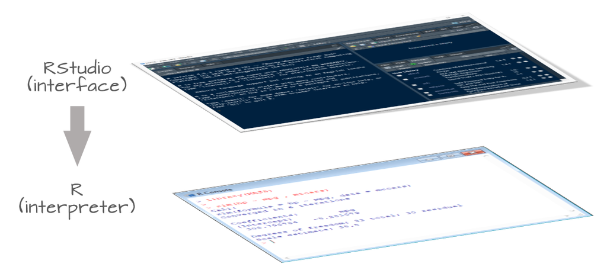

Image Credit: [Exploratory Data Analysis in R](https://mgimond.github.io/ES218/), by Manny Gimond

- **New install:** To install RStudio, visit posit.co/downloads/. Download the free (“Open Source Edition”) Desktop version for your operating system. Be sure to install the most up-to-date version available.
- **Launch RStudio:** Ensure RStudio opens and is running properly.

**Tip 1.1: Windows Users: You may need to install RTools**

**If you see a warning message after running `install.packages()`, install RTools.**

**Mac Users: You may need to install command line tools and XQuartz.**

**If RStudio prompts you to install Command Line Tools upon opening, go ahead and install them.**

- **To install command line tools** (if you’re not automatically prompted), run `xcode-select --install` in the RStudio Terminal
- **To install XQuartz,** visit [xquartz.org](https://www.xquartz.org/)

*Windows users: Windows machines should already have command line tools installed, and XQuartz is only required for Macs.*

## 3. Updating RStudio

If you already have RStudio and need to update, open RStudio, and under *Help* (in the top menu), choose *Check for updates*. If you have the most recent release, it will return *No update available. You are running the most recent version of RStudio*. Otherwise, you should follow the instructions to install an updated version.

You can also find the most up-to-date release of RStudio available for download at https://posit.co/download/rstudio-desktop/.

You might need to update your RTools as well, see Tip Windows Users: You may need to install RTools.

After installing the update, open RStudio and look at your Console to see what version is running:

[figure not shown]

If you notice an older version is running, go to Tools in the top menu bar and click “Global Options”:

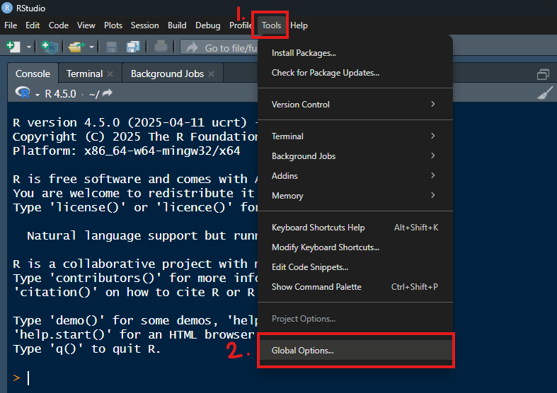

In the Global Options window, make sure you’re in General and click the “Change” button next to the “R version” field under the “R Sessions” header:

[figure not shown]

The “Choose R Installation” window will appear, and you can either choose the default option or you can specify a specific version of R. Either one works, then click “Ok”. You’ll be told to quit and restart RStudio for the changes to go into effect.

[figure not shown]